# MCTS for Cyber

We will jump right to the POMDP problem with two nodes:

Time is discrete (0,1,2,3,4,5...).

We define a window length, $w$.

We define an anomaly threshold, $k$.

We are starting with a partially observable decision process. The "state" at time $t$ consists of the number of messages sent in time $t-1, t-2, t-3...t-w.$ The state also includes whether or not the attacker has infected the subsequent node and whether or not the alarm has went off.

The observation is only the messages the attacker has sent

At each time-step here is the sequence of events

- The attacker sees the observation.
- He then chooses whether to send a message or not.
- If the attacker does send a malicious message, then 'B' becomes infected with probability, $p$
- with probability $q$, 'A' sends a normal message to 'B'
- Then if the sum of all messages sent from 'A' to 'B' (that is both the normal and malicious messages) in time $t, t-1, t-2,....t-w > k$, then the alarm sounds.
- The attacker receives a reward of 1 if infects 'B' before the alarm sounds.

We are going to use MCTS for this

## A note on beliefs

The reason we would need beliefs is if we wanted to prune the tree. For example, suppose we knew the optimal action for the attacker in the first stage of the game. To avoid starting at that node, we could start at the attackers second decision node. However, the attacker's second node is a record of history and actions, not the state. Nevertheless, we want to be able to simulate the *state* transitions. Therefore, we need to be able to draw from distirbution of current states.

```python
import numpy as np
import random
import copy
from matplotlib import pyplot as plt
%matplotlib inline
```

```python
"""
MCTS for the cyber project with no pruning.  Will be following
the algorithm in Mykel's book which I think is based off of
"Monte-Carlo Planning in Large POMDPs"
(POMCP Algorithm 1).  This algorithm will only work for
2-node nets as a proof of concept.

Note here that the history completely determines the observation
so we don't need to keep track of observation, just the history
"""


import numpy as np
import random
import copy
#Parameters
p = .01 # Infection probability
q =.5  # Background probability
w = 50 # Window
k =45 # Threshold
gamma = 1

class TwoNodeMCTS(object):
    def __init__(self, p=p, q=q, w=w, k=k,gamma=gamma, default_policy =.5, c=5):
        self.p = p # Infection probability
        self.q =q  # Background probability
        self.w = w # Window
        self.k = k # Threshold
        self.gamma = gamma # Discount
        self.dp = default_policy # Rollout policy of sending a message
        self.c = c

    def draw_s_o_r(self, current_state, action):
        """
        Returns the next state, observation and reward for
        a given current action and reward.
        """
        newstate = current_state[1:]
        backgroundmessage = int( random.random() < self.q )
        newstate.append(backgroundmessage + action)
        if np.sum(newstate) > self.k:
            newstate='Alarm'
        elif random.random() * action > 1-self.p:
            newstate = 'Infected'
        return newstate

    def draw_s0(self):
        s0  = list(np.random.binomial(1, self.q, size=self.w))
        while np.sum(s0) > self.k:
            s0 = list(np.random.binomial(1, self.q, size=self.w))
        return s0

    def search(self, num_samps=5000):
        T= {}
        noactu = []
        actu = []
        for i in xrange(num_samps):
            s= self.draw_s0()
            r, T = self.simulate(s, list(np.int_(np.zeros(self.w))),T, returnT=True)
            t0 =  T[str(list(np.int_(np.zeros(self.w))))]
            noactu.append(t0[0][0])
            actu.append(t0[1][0])
        return r, T, noactu, actu

    def rollout(self, s, h):
        if s == 'Alarm':
            return 0
        if s =='Infected':
            return 1
        action = int(np.random.random() < self.dp)
        new_state = self.draw_s_o_r(s, action)
        h.append(action)
        return self.gamma * self.rollout(new_state, h)



    def simulate(self, s, history, T = {}, returnT=False):
        """
        T is a dictionary keyed by histories.
        values are 3 element lists.  The first is the Q
        value and the second is the count. The third keeps
        track of the total.

        Only terminal rewards.

        Might want to convert the history to asci as it should be
        less in memory...maybe?
        """
        if s == 'Alarm':
            return 0
        if s =='Infected':
            return 1
        if str(history) not in T:
            T[str(history)] = [[0,0], [0,0], 0] # Also stores state count
            if returnT:
                return self.rollout(s, history), T
            else:
                return self.rollout(s, history)
        this_history = T[str(history)]
        action = np.argmax([this_history[0][0]
                            + self.c*(this_history[2] / float(this_history[0][1] + 1))**.5,
                            this_history[1][0]
                            + self.c*(this_history[2] / float(this_history[1][1]+ 1))**.5])
        updated_history = copy.copy(history)
        updated_history.append(action)
        newstate = self.draw_s_o_r(s, action)
        R = self.gamma * self.simulate(newstate, updated_history, T)
        T[str(history)][action][1]  += 1
        T[str(history)][action][0] += (R - T[str(history)][action][0])/float(T[str(history)][action][1])
        T[str(history)][2] += 1
        if returnT:
            return R, T
        else:
            return R

    # This should update T and output the final history Q,N pairs.
    # Just need to write rollout function
```

```python
test = TwoNodeMCTS()
y=test.search()
```

## Simple Example

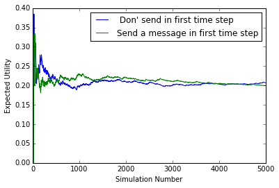

```python
plt.plot(y[2], label= ' Don\' send in first time step')
plt.plot(y[3], label = 'Send a message in first time step')
plt.ylabel('Expected Utility')
plt.xlabel('Simulation Number')
plt.legend()
```

## Parameter Sweeps

The parameters above were:

- $p$ = .01 # Infection probability
- $q$ =.5 # Background Message probability
- $w$ = 50 # Window
- $k$ =45 # Threshold
- $\gamma$ = 1 # Discount

## Varying the discount rate from .1 to .9 by .1

```python
res_discount = []
for gam in np.arange(.1,1,.1):
    test = TwoNodeMCTS(gamma=gam)
    y=test.search()
    res_discount.append([y[2], y[3]])
```

[output not shown]

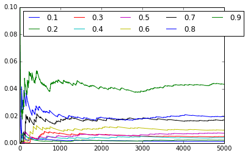

```python
for ix in range(len(np.arange(.1,1,.1)) - 1):
    #plt.plot(res_discount[ix][0], color='red')
    plt.plot(res_discount[ix][1], label = np.arange(.1,1,.1)[ix])
ix +=1
#plt.plot(res_discount[ix][0], color='red', label = 'Don\'t Send')
plt.plot(res_discount[ix][1], label = .9)
plt.legend(loc=2, ncol=5)
plt.ylim(0,.1)
```

## Varying The infection Probability from .05 to .3 by .05

```python
res_ip = []
for ip in np.arange(.05,.35,.05):
    print ip
    test = TwoNodeMCTS(gamma=1, p=ip)
    y=test.search()
    res_ip.append([y[2], y[3]])
```

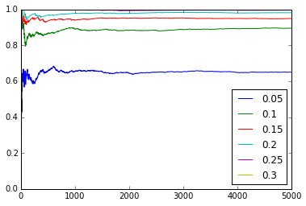

```python
for ix in range(len(np.arange(.05,.35,.05)) - 1):
    #plt.plot(res_ip[ix][0], color='red')
    plt.plot(res_ip[ix][1], label =np.arange(.05,.35,.05)[ix])
ix +=1
#plt.plot(res_ip[ix][0], color='red', label = 'Don\'t Send')
plt.plot(res_ip[ix][1], label = .3)
plt.legend(loc=4)
```

## Varying threshold from 20 to 45 by 5. (Infection probability= .15)

(Note this is a simplified version of varying the defenders strategy)

```python
res_thresh = []
for k in np.arange(20,50,5):
    test = TwoNodeMCTS(gamma=1, k=k, p =.15)
    y=test.search()
    res_thresh.append([y[2], y[3]])
```

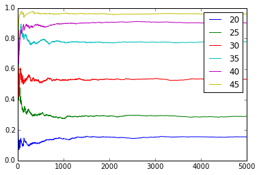

```python
for ix in range(len(np.arange(20,50,5))):
    plt.plot(res_thresh[ix][1], label =np.arange(20,50,5)[ix])
    plt.legend()
```

Next Steps:

- Implement with a general network (More than 2 nodes)
  - This should be fairly straighforward. Just need to update the history and next state function. The rest should fall into place.
- Implement Defender's best response